# Tp53 SNV hotspots

K S Gaonkar (D3B)

In this notebook we will add TP53 alteration status as discussed in [#837](https://github.com/AlexsLemonade/OpenPBTA-analysis/issues/837):

**TP53 altered - loss**, if :

- A sample contains a TP53 hotspot SNV mutation. (Cancer hotspot database and downloadable file available). Please also crosscheck that all mutations from this table are included.
- A sample contains two TP53 alterations, suggesting (but not confirming) that both alleles are affected (SNV+SNV, CNV+SNV).
- A sample contains one alteration (SNV or CNV) + has cancer_predispositions == “Li-Fraumeni syndrome”, suggesting there is a germline variant in addition to the somatic variant we observe.
- A sample does not have a TP53 alterations, but has cancer_predispositions == “Li-Fraumeni syndrome” and TP53 classifier score for matched RNA-Seq > 0.5 (or higher cutoff we decide upon later).

**TP53 altered - activated**, if:

- A sample contains one of the two TP53 activating mutations R273C and R248W. Reference and reference.

## Setup

```r
library("ggpubr")
library("ggthemes")
library("tidyverse")
library("ggfortify")
library("broom")

# rootdir
root_dir <- rprojroot::find_root(rprojroot::has_dir(".git"))
data_dir <- file.path(root_dir, "data")

input_dir <- file.path(root_dir,
                         "analyses",
                         "tp53_nf1_score",
                         "input")
# cell composition
cell_line_composition <- read_tsv(file.path("..",
                                            "molecular-subtyping-HGG",
                                            "input",
                                            "cell-line-composition.tsv"),
                                  col_types =
                                    readr::cols( aliquot_id  = readr::col_character()))

# histology
 histology <- read_tsv(file.path(data_dir,"pbta-histologies.tsv")) %>%
   select("Kids_First_Biospecimen_ID",
          "sample_id",
          "cancer_predispositions",
          "sample_type",
          "experimental_strategy",
          "composition") %>%
   # merge cell line composition
  left_join(cell_line_composition)
# Cancer database
hotspot_database_2017_tp53_snv <- readxl::read_xls(file.path(input_dir,"hotspots_v2.xls"),sheet = 1) %>%
  filter(Hugo_Symbol == "TP53")
hotspot_database_2017_tp53_indel <- readxl::read_xls(file.path(input_dir,"hotspots_v2.xls"),sheet = 2) %>%
  filter(Hugo_Symbol == "TP53")

# p53, p63 and p73 functional sites
functional_sites_tp53 <- read_tsv(file.path(input_dir,"hotspot_Chen_2006.tsv"))
results_dir <- file.path(root_dir,
                         "analyses",
                         "tp53_nf1_score",
                         "results")

if (!dir.exists(results_dir)) {
  dir.create(results_dir)
}

# classifier scores
classifier_score_stranded <- read_tsv(
  file.path(
    results_dir,
    "pbta-gene-expression-rsem-fpkm-collapsed.stranded_classifier_scores.tsv"))%>%
  select(sample_id,tp53_score)
classifier_score_polya <-read_tsv(
  file.path(
    results_dir,
    "pbta-gene-expression-rsem-fpkm-collapsed.polya_classifier_scores.tsv")) %>%
  select(sample_id,tp53_score)
classifier_score<- rbind(classifier_score_polya,classifier_score_stranded) %>%
  rename(Kids_First_Biospecimen_ID_RNA=sample_id) %>%
  left_join(histology ,by=c("Kids_First_Biospecimen_ID_RNA"="Kids_First_Biospecimen_ID"))

# Copy number per sample
# overlapping functional domain
cnv_domain_overlap <- read_tsv(
  file.path(
    results_dir,
    "loss_overlap_domains_tp53.tsv"))
```

### Check if all function sites are in hotspots

All functional sites are just 1 base so checking in `hotspot_database_2017_snv`

```r
functional_sites_tp53 %>%
  filter(!gsub("[A-Z|a-z]","",p53) %in% hotspot_database_2017_tp53_snv$Amino_Acid_Position )
```

| p53 | p63 | p73 |
| --- | --- | --- |
| A276 | A307 | A296 |
| R283 | K314 | K303 |

2 functional sites are missing in hotspots database.

## SNV for TP53

Removing Silent or Intron classified variants to capture only putative damaging mutations

```r
consensus_tp53_snv_indel <- data.table::fread(
  file.path(data_dir,"pbta-snv-consensus-mutation.maf.tsv.gz"),
                                   select = c("Chromosome",
                                              "Start_Position",
                                              "End_Position",
                                              "Strand",
                                              "Variant_Classification",
                                              "Tumor_Sample_Barcode",
                                              "Hugo_Symbol",
                                              "HGVSp_Short"),
                                   data.table = FALSE) %>%
  filter(Hugo_Symbol == "TP53") %>%
  filter(!(Variant_Classification %in% c("Silent", "Intron",
                                         # remove other non-amino acid SNVs
                                         "3'Flank" ,"5'Flank",
                                         "3'UTR", "5'UTR"  )))
```

### Gather annotation for SNV

hotspots : overlaps AA position which are statistically significant SNV/Indels activating : overlaps AA position which are found to act as gain-of-function according to literature

```r
consensus_tp53_snv_indel <- consensus_tp53_snv_indel %>%
  mutate(
    hotspot = case_when(
      # strip REF and Variant AA to get Amino_Acid_Position in consensus maf
      (gsub("[A-Z|a-z]|[.]","",HGVSp_Short) %in%
         # if overlaps the hotspot Amino_Acid_Position
         hotspot_database_2017_tp53_snv$Amino_Acid_Position)  ~ 1,
      TRUE ~ 0),
    activating = case_when(
      # strip REF and Variant AA to get Amino_Acid_Position in consensus maf
      (gsub("[A-Z|a-z]|[.]","",HGVSp_Short) %in%
         # if overlaps the activating  Amino_Acid_Position
         c("273","248"))  ~ 1,
      TRUE ~ 0
    )
  )
```

## Gather SNV,CNV, classifier and cancer_predisposition values

We will gather values per sample_id since DNA and RNA samples can be only matched by `sample_id`

```r
tp53_alterations_dna <- histology %>%
  filter(experimental_strategy != "RNA-Seq") %>%
  # merge cell line composition
  left_join(cell_line_composition) %>%
  # filter for Tumors
  filter(sample_type=="Tumor") %>%
  # join consensus calls overlapping hotspots
  left_join(consensus_tp53_snv_indel,
            by=c("Kids_First_Biospecimen_ID"="Tumor_Sample_Barcode")) %>%
  # join filtered cnv losses
  left_join(cnv_domain_overlap,by=c("Kids_First_Biospecimen_ID"="biospecimen_id",
                                    "sample_id")) %>%
  rename(Kids_First_Biospecimen_ID_DNA = Kids_First_Biospecimen_ID)
tp53_alterations_score <- tp53_alterations_dna %>%
  # add classifier score
  full_join(classifier_score,by=c("sample_id",
                                  "cell_line_composition",
                                  "cancer_predispositions",
                                  "sample_type",
                                  "Kids_First_Participant_ID")) %>%
  # select useful columns
  select(sample_id,Kids_First_Biospecimen_ID_RNA,Kids_First_Biospecimen_ID_DNA,
         tp53_score,cancer_predispositions,HGVSp_Short,copy_number,hotspot,activating) %>%
  arrange(sample_id) %>%
  unique() %>%
  replace_na(list(hotspot = 0, activating = 0))

tp53_alterations_score
```

| sample_id | Kids_First_Biospecimen_ID_RNA | Kids_First_Biospecimen_ID_DNA | tp53_score | cancer_predispositions | HGVSp_Short | copy_number | hotspot | activating |
| --- | --- | --- | --- | --- | --- | --- | --- | --- |
| 7316-10 | BS_GDHH6T5A | BS_1RFBH1SP | 0.233944870 | NF-1 | NA | NA | 0 | 0 |
| 7316-100 | BS_BHR08WGW | BS_SFZ3A07S | 0.408286009 | None documented | NA | NA | 0 | 0 |
| 7316-101 | BS_QV51J756 | BS_4RS1SC48 | 0.610210704 | None documented | NA | NA | 0 | 0 |
| 7316-1038 | BS_VPBMDMQX | NA | 0.779995805 | None documented | NA | NA | 0 | 0 |
| 7316-104 | BS_Y08D5P8N | BS_MRX1SPFB | 0.251909996 | None documented | NA | NA | 0 | 0 |
| 7316-1052 | BS_TGS109T3 | NA | 0.852085804 | None documented | NA | NA | 0 | 0 |
| 7316-1055 | BS_H1ZS5FMZ | NA | 0.903617965 | None documented | NA | NA | 0 | 0 |
| 7316-1057 | BS_58YXHGAJ | NA | 0.575641146 | None documented | NA | NA | 0 | 0 |
| 7316-1059 | BS_C41DJZ1F | NA | 0.442893058 | NF-1 | NA | NA | 0 | 0 |
| 7316-1060 | BS_Z8F3GM85 | NA | 0.845411500 | None documented | NA | NA | 0 | 0 |

[output cut: 1146 more lines]

Convert the above to wide format

```r
tp53_alterations_score_wide <- tp53_alterations_score %>%
  # group
  group_by(sample_id,
           Kids_First_Biospecimen_ID_DNA,
           Kids_First_Biospecimen_ID_RNA,
           cancer_predispositions,
           tp53_score) %>%
  #
  # sample_id as rows add SNV counts,CNV loss counts
  # and hotspot/activating mutation annotation
  summarise(
    # summarize length of SNV and CNV alterations
    SNV_indel_counts= length(unique(HGVSp_Short[!is.na(HGVSp_Short)])),
    CNV_loss_counts = length(unique(copy_number[!is.na(copy_number)])),
    HGVSp_Short = toString(unique(HGVSp_Short)),
    CNV_loss_evidence = toString(unique(copy_number)),
    # summarize unique hotspot values per sample_id
    hotspot = max(unique(hotspot[!is.na(hotspot) ])),
    activating = max(unique(activating[!is.na(activating)])))

tp53_alterations_score_wide
```

| sample_id | Kids_First_Biospecimen_ID_DNA | Kids_First_Biospecimen_ID_RNA | cancer_predispositions | tp53_score | SNV_indel_counts | CNV_loss_counts | HGVSp_Short | CNV_loss_evidence | hotspot | activating |
| --- | --- | --- | --- | --- | --- | --- | --- | --- | --- | --- |
| 7316-10 | BS_1RFBH1SP | BS_GDHH6T5A | NF-1 | 0.233944870 | 0 | 0 | NA | NA | 0 | 0 |
| 7316-100 | BS_SFZ3A07S | BS_BHR08WGW | None documented | 0.408286009 | 0 | 0 | NA | NA | 0 | 0 |
| 7316-101 | BS_4RS1SC48 | BS_QV51J756 | None documented | 0.610210704 | 0 | 0 | NA | NA | 0 | 0 |
| 7316-1038 | NA | BS_VPBMDMQX | None documented | 0.779995805 | 0 | 0 | NA | NA | 0 | 0 |
| 7316-104 | BS_MRX1SPFB | BS_Y08D5P8N | None documented | 0.251909996 | 0 | 0 | NA | NA | 0 | 0 |
| 7316-1052 | NA | BS_TGS109T3 | None documented | 0.852085804 | 0 | 0 | NA | NA | 0 | 0 |
| 7316-1055 | NA | BS_H1ZS5FMZ | None documented | 0.903617965 | 0 | 0 | NA | NA | 0 | 0 |
| 7316-1057 | NA | BS_58YXHGAJ | None documented | 0.575641146 | 0 | 0 | NA | NA | 0 | 0 |
| 7316-1059 | NA | BS_C41DJZ1F | NF-1 | 0.442893058 | 0 | 0 | NA | NA | 0 | 0 |
| 7316-1060 | NA | BS_Z8F3GM85 | None documented | 0.845411500 | 0 | 0 | NA | NA | 0 | 0 |

[output cut: 1120 more lines]

### Add annotation

As discussed above we want to annotate TP53 mutants that are putative loss-of-function OR gain-of-function.

```r
tp53_alterations_score_wide <- tp53_alterations_score_wide %>%
  mutate(
    # add tp53_altered annotation column
    tp53_altered =
      case_when(
        # when activating == 0
        activating == 0 &
          # check if mutated variant AA position overlaps hotspot database
          ( hotspot == 1  |
              # check if sample_id has SNV+CNV mutation
              # suggesting both alleles are mutated
              (SNV_indel_counts >= 1 & CNV_loss_counts >=1) |
              # check if more than 1 SNV is present
              # suggesting both alleles are mutated
              SNV_indel_counts > 1 |
              # check if SNV mutant and has
              # Li-Fraumeni syndrome suggesting
              # germline TP53 mutant as cancer predisposition
              (SNV_indel_counts >= 1 &
                             grepl("Li-Fraumeni syndrome",cancer_predispositions)) |
              # check if CNV mutant  and has
              # Li-Fraumeni syndrome suggesting
              # germline TP53 mutant as cancer predisposition
              (CNV_loss_counts >= 1 &
                             grepl("Li-Fraumeni syndrome",cancer_predispositions)) |
              # check if tp53 inactivating score for RNA_Seq is greater that 0.5
              # and has Li-Fraumeni syndrome suggesting
              # germline TP53 mutant as cancer predisposition
              (tp53_score > 0.5 &
                             grepl("Li-Fraumeni syndrome",cancer_predispositions)) |
              # check if tp53 inactivating score for RNA_Seq is greater that 0.5
              # and has 1 or more SNV| CNV loss in TP53
              (tp53_score > 0.5 &
                             (SNV_indel_counts >= 1 | CNV_loss_counts >=1))
          ) ~ "loss",
        # when activating == 1
        activating == 1 ~ "activated",
        # if no evidence supports TP53 inativation or activation
        TRUE ~ "Other"
      )
  )
```

## Explore distribution of tp53_altered status vs tp53 inactivation scores

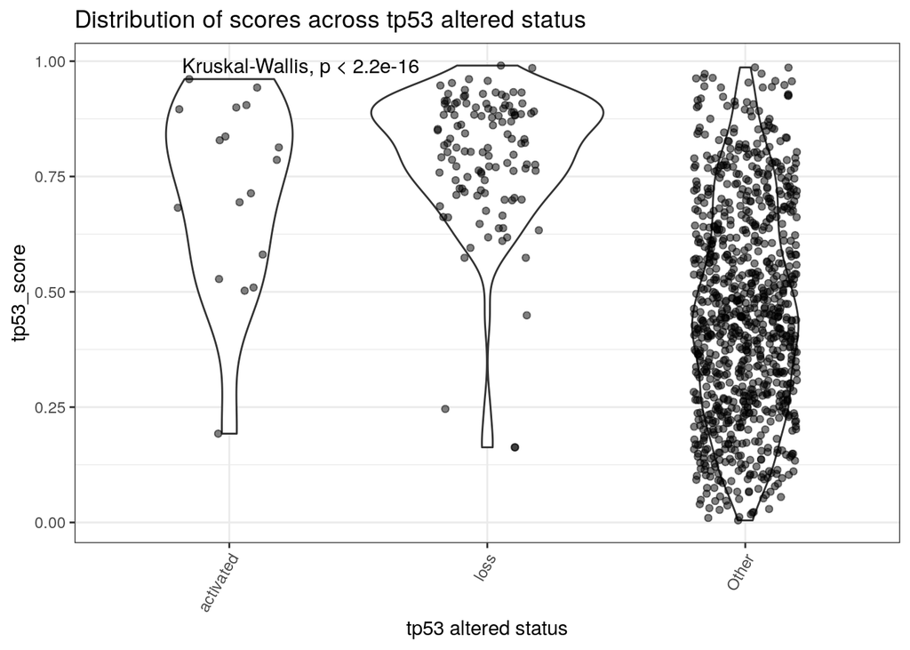

```r
ggplot(tp53_alterations_score_wide, aes(x = factor(tp53_altered), y = tp53_score)) +
  geom_violin()+
  geom_jitter(alpha = 0.5, width = 0.2) +
  stat_compare_means() +
  theme_bw() +
  ggtitle("Distribution of scores across tp53 altered status") +
  theme(axis.text.x = element_text(angle = 60, hjust = 1))+
  xlab("tp53 altered status")
```

TP53 mutants with gain-of-function (activating) mutants promote tumorigenesis according to literature. [Reference](https://pubmed.ncbi.nlm.nih.gov/17417627/) and [reference](https://pubmed.ncbi.nlm.nih.gov/24677579/) have similar distribution of classifier scores to that of potential loss-of-function (multi-allelic) Tp53 mutations.

“Other” annotated samples either don’t have any high-confidence loss/gain TP53 SNVs nor CNV losses OR DNA sample is not available.

### (stranded) Expression profile for activating vs loss TP53 status

```r
stranded <- readRDS(file.path(data_dir,"pbta-gene-expression-rsem-fpkm-collapsed.stranded.rds"))

# subset to TP53
subset_stranded <- t(stranded)[,"TP53"]

stranded_tp53 <- as.data.frame(subset_stranded) %>%
  rename(TP53=subset_stranded) %>%
  rownames_to_column() %>%
  left_join(tp53_alterations_score_wide,by=c("rowname"="Kids_First_Biospecimen_ID_RNA")) %>%
  # remove polya from matched scores
  filter(tp53_altered %in% c("activated","loss"))
```

Plot distribution of TP53 gene expression (stranded)

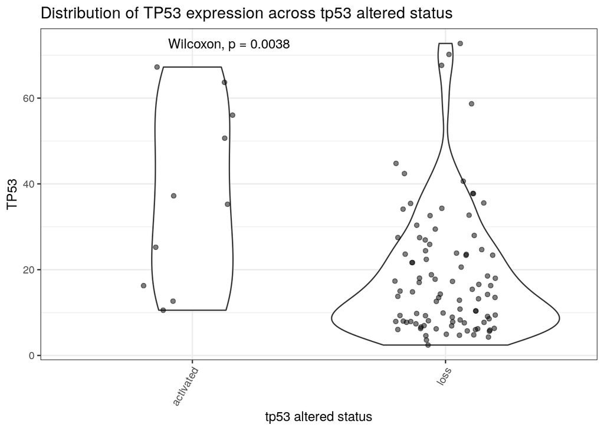

```r
ggplot(stranded_tp53, aes(x = factor(tp53_altered), y = TP53)) +
  geom_violin()+
  geom_jitter(alpha = 0.5, width = 0.2) +
  stat_compare_means() +
  theme_bw() +
  ggtitle("Distribution of TP53 expression across tp53 altered status") +
  theme(axis.text.x = element_text(angle = 60, hjust = 1))+
  xlab("tp53 altered status")
```

### (poly-a) Expression profile for activating vs loss TP53 status

```r
polya <- readRDS(file.path(data_dir,"pbta-gene-expression-rsem-fpkm-collapsed.polya.rds"))

# subset to TP53
subset_polya <- t(polya)[,"TP53"]

polya_tp53<- as.data.frame(subset_polya) %>%
  rename(TP53=subset_polya) %>%
  rownames_to_column() %>%
  left_join(tp53_alterations_score_wide,by=c("rowname"="Kids_First_Biospecimen_ID_RNA")) %>%
  filter(tp53_altered %in% c("activated","loss"))
```

Plot distribution of TP53 gene expression (poly-a)

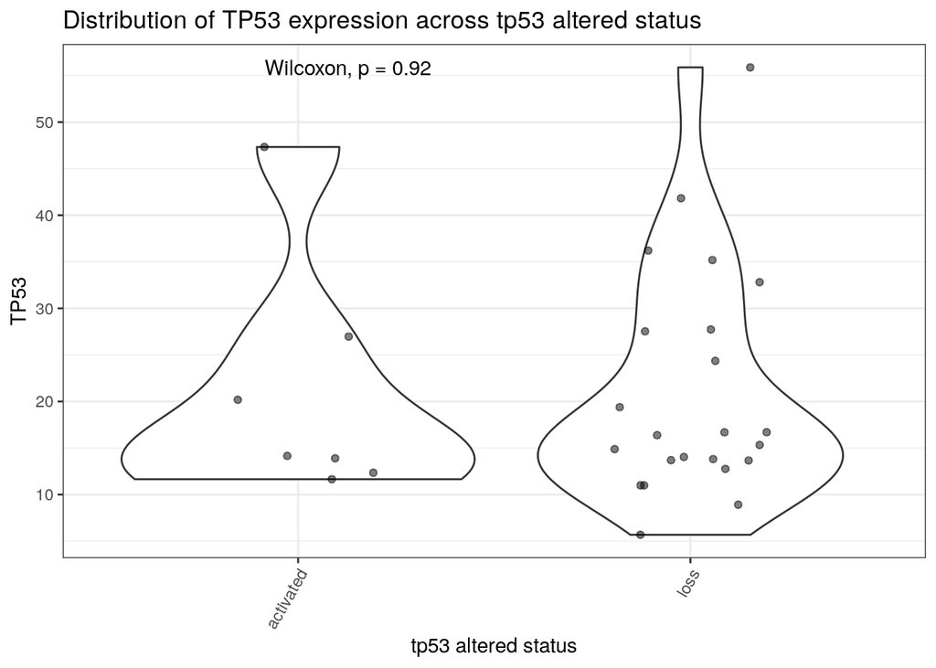

```r
ggplot(polya_tp53, aes(x = factor(tp53_altered), y = TP53)) +
  geom_violin()+
  geom_jitter(alpha = 0.5, width = 0.2) +
  stat_compare_means() +
  theme_bw() +
  ggtitle("Distribution of TP53 expression across tp53 altered status") +
  theme(axis.text.x = element_text(angle = 60, hjust = 1))+
  xlab("tp53 altered status")
```

### Check if other cancer predisposition have high TP53 inactivation scores

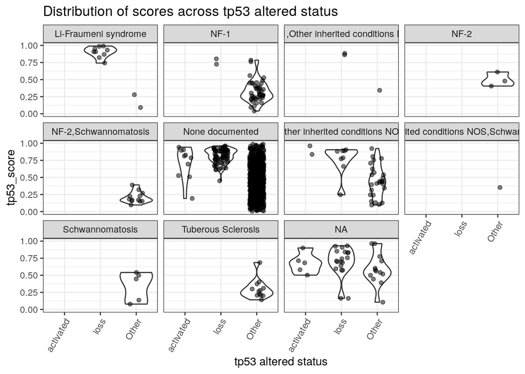

```r
ggplot(tp53_alterations_score_wide, aes(x = factor(tp53_altered), y = tp53_score)) +
  geom_violin()+
  geom_jitter(alpha = 0.5, width = 0.2) +
  theme_bw() +
  ggtitle("Distribution of scores across tp53 altered status") +
  theme(axis.text.x = element_text(angle = 60, hjust = 1))+
  xlab("tp53 altered status") +
  facet_wrap(.~cancer_predispositions)
```

Some NF-1 and/or Other inherited conditions NOS have high scoring TP53 mutants as well.

Interesting 2 bs ids annotated with Li-Fraumeni synfrome pre-disposition have very low tp53 classifier scores.

```r
tp53_alterations_score_wide %>%
  filter(cancer_predispositions == "Li-Fraumeni syndrome",
         tp53_score < 0.5)
```

| sample_id | Kids_First_Biospecimen_ID_DNA | Kids_First_Biospecimen_ID_RNA | cancer_predispositions | tp53_score | SNV_indel_counts | CNV_loss_counts | HGVSp_Short | CNV_loss_evidence | hotspot | activating | tp53_altered |
| --- | --- | --- | --- | --- | --- | --- | --- | --- | --- | --- | --- |
| 7316-2310 | BS_Z9PKZ4RT | BS_DEHJF4C7 | Li-Fraumeni syndrome | 0.09144265 | 0 | 0 | NA | NA | 0 | 0 | Other |
| 7316-445 | BS_G9MQM1KK | BS_ZD5HN296 | Li-Fraumeni syndrome | 0.27898380 | 0 | 0 | NA | NA | 0 | 0 | Other |

## Save file

Adding DNA and RNA biospecimen ids to `tp53_alterations_score_wide` and saving

```r
tp53_alterations_score_wide %>%
  write_tsv(file.path(results_dir,"tp53_altered_status.tsv"))
```